# 1 Instalacion de software

1. Instalá o actualizá R en el ordenador que utilizarás durante el curso (https://cran.r-project.org). Asumo que ya lo tenés instalado, pero intentá actualizarlo si tenés una versión de R < 4.0.0. Puedes averiguar qué versión de R tenés ejecutando esto en la consola de R:

**Código**

```r
version$version.string
```

2. Actualizá todos los paquetes de R si ya tenías instalado R (⚠️ este paso puede tardar mucho en ejecutarse ⚠️):

**Código**

```r
update.packages(ask = FALSE)
```

3. Instalá R en la computadora que utilizarás durante el curso (https://cran.r-project.org/). Probablemente ya lo tenés instalado, pero intentá actualizarlo si tenés una versión de R < 4.0.0. Podés encontrar qué versión de R tenés ejecutando esto en la consola de R:

**Código**

```r
version$version.string
```

4. Instalá la interfaz de RStudio (https://posit.co/download/rstudio-desktop/, elejí la versión gratuita).
5. Abrí RStudio y seleccioná la pestaña “Tools” y luego “Global options” (última opción). Seleccioná la opción “Code”, luego seleccioná la casilla de “Soft wrap”.
6. También en Rstudio: Seleccioná la opción “Pane Layout” y mové “Source” al panel superior izquierdo y “Console” al panel superior derecho. Esta disposición asigna más espacio en la pantalla a los paneles más útiles. Dalé “Apply” y “Ok”. Para aquellos que no estén familiarizados con RStudio, “Source” es un editor de texto donde se escribe el código y donde guardas el código en un archivo físico (normalmente en formato .R) y la consola evalúa el código que se envia desde el “Source” e imprime los resultados (si los hay). Podés escribir código en la consola, pero no se guardará en un archivo físico.
7. Ahora en la consola de R en Rstudio ejecutá el siguiente código para instalar los paquetes que estaremos usando durante el curso:

**Código**

```r
# instalar paquete sketchy para instalar otros paquetes y creer proyectos
if (!require("sketchy")) {
    install.packages("sketchy")
}

# cargar paquete
library(sketchy)

# instalar/ cargar paquetes
# instalar/ cargar paquetes
load_packages(
  packages = c(

    # manejo y formateo de datos
    "dplyr",
    "tidyr",
    "readxl",
    "writexl",

    # graficos
    "ggplot2",
    "RColorBrewer",
    "viridis",
    "scales",

    # estadistica descriptiva / tradicional
    "psych",
    "car",
    "MASS",

    # modelos de regresion y mixtos
    "lme4",
    "lmerTest",
    "MuMIn",
    "sjPlot",
    "glmnet",
    "nnet",

    # aprendizaje automatico / modelos predictivos
    "caret",
    "randomForest",
    "xgboost",
    "neuralnet",
    "rpart",
    "rpart.plot",
    "tree",

    # evaluacion de modelos
    "Metrics",
    "pROC",
    "themis",

    # reduccion de dimensionalidad
    "dimRed",

    # datos de ejemplo
    "ISLR",

    # tablas y reportes
    "kableExtra",
    "knitr",

    # varios
    "remotes",

    # paquete de github (no esta en CRAN)
    github = "hadley/emo"
  )
)
```

8. Creá un proyecto para el curso corriendo este código:

**Código**

```r
library(sketchy)

make_compendium(
  name = "r_avanzado",
  path = "DIRECTORIO_DONDE_HACER_EL_PROYECTO",
  Rproj = TRUE,
  readme = TRUE
)
```

*(en realidad este es tambien un [compendio de investigación](https://marce10.github.io/ciencia_reproducible/compendios_de_investigacion.html))*

Abrí el proyecto en Rstudio:

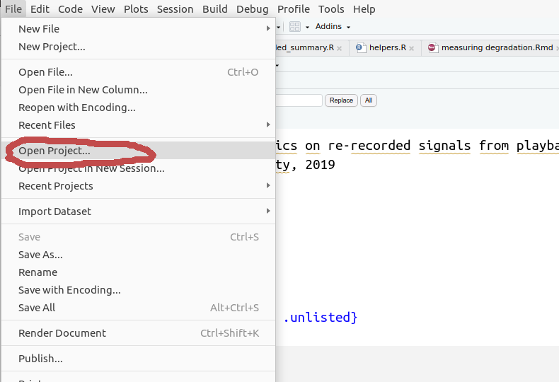

Este proyecto debe usarse cada vez que se trabaja código del curso ✌️

# 2 Recursos adicionales

- Introducción a Rstudio [video](https://www.youtube.com/watch?v=skPzCkvr8Cw)
- kaggle: juegos de datos de ejemplo [link](https://www.kaggle.com/datasets?search=psychology):
- [Datos para classificar personalidad](https://www.kaggle.com/datasets/anshulmehtakaggl/60k-responses-of-16-personalities-test-mbt)
- R data sets: [link](https://vincentarelbundock.github.io/Rdatasets/articles/data.html)